Skip to content

Trial biostatistics toolkit

# SIMBE01 PK and Bioequivalence Results

Synthetic 2x2 crossover worked example: results report

Synthetic data only: simulated for this worked example; not real trial data and not a regulatory deliverable. Every number below is computed by `study/run_all.R` from code in this repository.

## Summary

Bioequivalence of the test tablet (T) to the reference tablet (R) was **shown** for both primary parameters in 38 participants (bioequivalence set). The ratio of geometric means T/R was 101.07% for Cmax (90% CI 98.89% to 103.30%) and 103.99% for AUC(0-t) (90% CI 98.52% to 109.75%), both within 80.00% to 125.00% (ICH M13A). The supportive AUC(0-inf) ratio was 104.62% (98.63% to 110.97%) in the 37 participants whose AUC(0-inf) met the SAP parameter rules in both periods.

The within-participant CV was 5.6% for Cmax and 14.0% for AUC(0-t), below the 25% assumed in the sample size, so both intervals are narrower than planned. In this simulation Cmax varies little within a participant because the simulator’s occasion-to-occasion variability acts on clearance.

## Analysis sets and exclusions

| Analysis set | Participants |
| --- | --- |
| Enrolled (randomized) | 40 |
| Safety | 40 |
| PK concentration | 40 |
| PK parameter | 40 |
| Bioequivalence | 38 |

Periods with an exclusion rule triggered or a measurable pre-dose concentration

| Participant | Period | Treatment | Pre-dose (% of Cmax) | Decision |
| --- | --- | --- | --- | --- |
| 008 | 2 | Test | 2.5 | kept (below the 5% rule) |
| 029 | 2 | Test | 0.0 | emesis within 2 h of dosing |

The simulated scenarios and what the SAP rules did with each (read from ADSL and the evaluated exclusion rules):

Documented scenarios (03_adam/sdtm/scenarios.json)

| Participant | Scenario | Period excluded | Bioequivalence set |
| --- | --- | --- | --- |
| 017 | withdraws consent after Period 1 (no Period 2 dose) | no | no |
| 029 | vomits 45 minutes after the Period 2 dose | emesis within 2 h of dosing | no |
| 008 | measurable Period 2 pre-dose concentration at 2.5% of that period's Cmax (below the 5% rule) | no | yes |
| 035 | 12 h sample in Period 1 not collected | no | yes |
| 012 | 4 h sample in Period 1 drawn 25 minutes late | no | yes |
| 024 | 6 h sample in Period 2 reported below the LLOQ between quantifiable samples (a simulated sample-handling problem; no reassay) | no | yes |

A withdrawn participant keeps the profiles they have in the PK summaries but has no data for the other product, so leaves the bioequivalence set. A missed sample is omitted and nothing is imputed.

## NCA

PKNCA 0.12.1 on actual sampling times (pre-dose samples at time 0), AUC by linear-up/log-down (linear when a concentration is 0), values below the LLOQ set to 0 wherever they fall and left out of the lambda z fit (`conc.blq = list(first = "keep", middle = "keep", last = "keep")`), lambda z from at least 3 points after tmax chosen by adjusted R-squared. The SAP parameter rules are applied with PKNCA `exclude()`: AUC(0-inf) is not summarized or analyzed when more than 20% is extrapolated, and lambda z-based parameters when the adjusted R-squared is below 0.90; the values stay in ADPP with NCAEXRSN set.

What the ICH M13A BLQ setting changes: the same NCA with the PKNCA default (a BLQ value between quantifiable samples dropped). Only values that differ are listed.

| Participant | Period | Treatment | Parameter | BLQ kept as 0 (ICH M13A, used) | PKNCA default (BLQ dropped) | Difference (%) |
| --- | --- | --- | --- | --- | --- | --- |
| 024 | 2 | Reference | AUCIFO | 1443.75 | 1564.60 | -7.7 |
| 024 | 2 | Reference | AUCLST | 1312.11 | 1432.96 | -8.4 |

ICH M13A acceptability checks (executed)

| Check | Result | Rule | Met |
| --- | --- | --- | --- |
| Participants with evaluable data for both products (bioequivalence set) | 38 of 40 (95.0%) | ICH M13A 2.2.3.1: at least 12 | yes |
| Profiles with AUC(0-t)/AUC(0-inf) below 80% | 2 of 78 (2.6%) | ICH M13A 2.2.2.2: discuss validity if more than 20% of profiles | yes |
| Profiles with fewer than 3 points in the terminal phase | 0 of 78 (0.0%) | SAP and ICH M13A: at least 3 points | yes |
| Profiles whose AUC(0-inf) is more than 20% extrapolated (AUC(0-inf) not summarized or analyzed) | 2 of 78 (2.6%) | SAP parameter rule: value kept in ADPP (NCAEXRSN), not summarized | yes |
| Profiles with adjusted R-squared below 0.90 (lambda z-based parameters not summarized or analyzed) | 0 of 78 (0.0%) | SAP parameter rule: values kept in ADPP (NCAEXRSN), not summarized | yes |
| Profiles with Cmax at the first post-dose sample | 2 of 78 (2.6%) | ICH M13A 2.1.8.1: discuss robustness; supplementary analysis 2 removes 2 participant(s) of the bioequivalence set | yes |
| Periods excluded for emesis within 2 h of dosing | 1 of 79 (1.3%) | SAP rule: documented before bioanalysis (ICH M13A 2.2.1) | yes |
| Periods excluded for a pre-dose concentration above 5% of Cmax | 0 of 79 (0.0%) | ICH M13A 2.2.3.3: exclude the period (applied to the bioanalytical results) | yes |
| Periods with AUC(0-t) below 5% of the product geometric mean (without the participant) | 0 of 79 (0.0%) | ICH M13A 2.2.1.1: may exclude, at most 1 participant (applied to the bioanalytical results) | yes |

## Concentrations

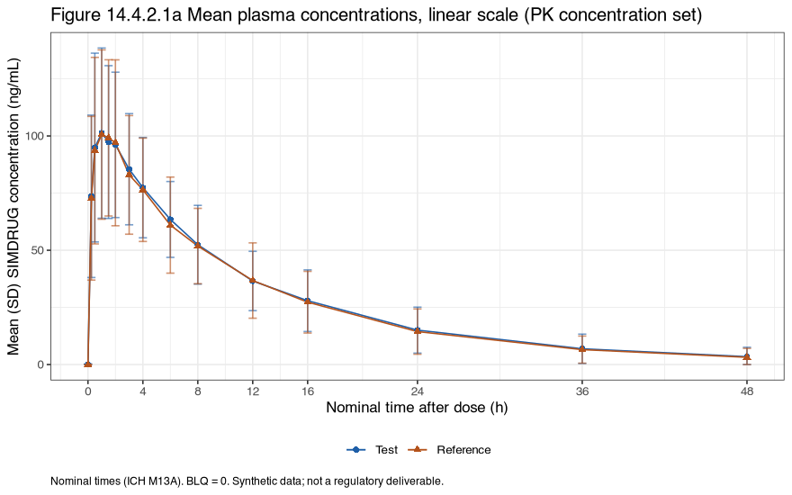

Mean concentrations (linear), nominal times

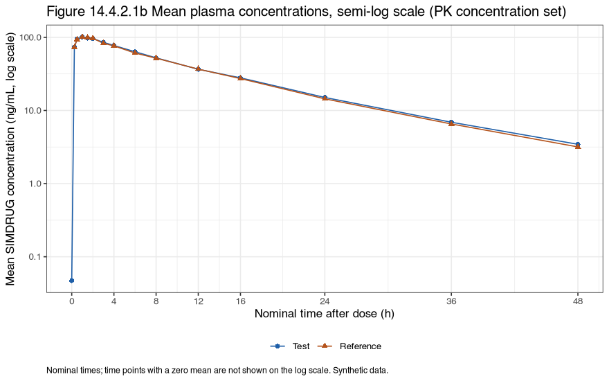

Mean concentrations (semi-log), nominal times

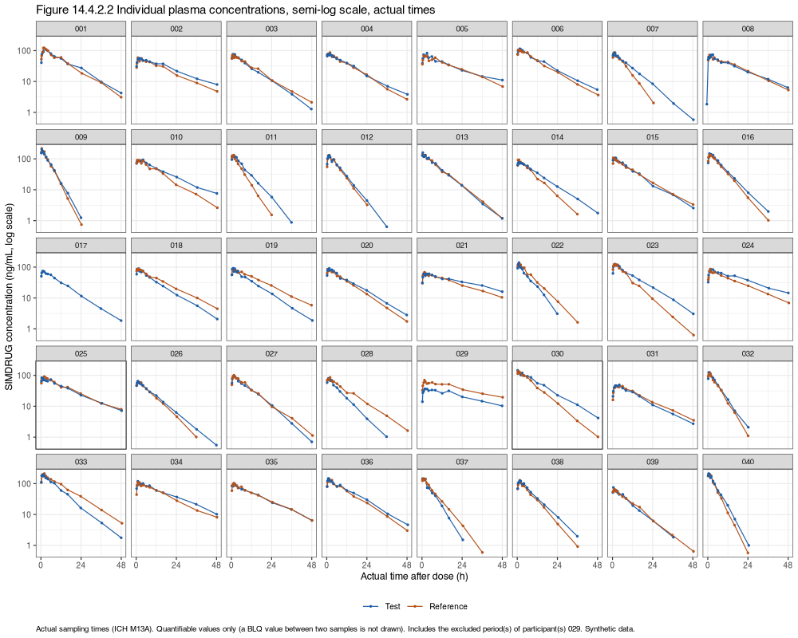

Individual concentrations (semi-log), actual times

Table 14.4.1.1 Summary of Plasma SIMDRUG Concentrations (ng/mL) by Nominal Time

PK concentration set

Study SIMBE01 (synthetic)

|  | Test | Reference |
| --- | --- | --- |
|  | (N=39) | (N=39) |
| Nominal time (h) |  |  |
| 0 (pre-dose) |  |  |
| n (n BLQ) | 39 (38) | 39 (39) |
| Mean (SD) | 0.05 (0.29) | 0.00 (0.00) |
| CV% | 624.5 | NE |
| Median | 0.00 | 0.00 |
| Min - Max | 0.00 - 1.84 | 0.00 - 0.00 |
| 0.25 |  |  |
| n (n BLQ) | 39 (0) | 39 (0) |
| Mean (SD) | 73.58 (35.52) | 72.76 (35.81) |
| CV% | 48.3 | 49.2 |
| Median | 66.30 | 63.80 |
| Min - Max | 20.90 - 180.00 | 16.10 - 177.00 |
| 0.5 |  |  |
| n (n BLQ) | 39 (0) | 39 (0) |
| Mean (SD) | 94.93 (41.29) | 93.58 (40.79) |
| CV% | 43.5 | 43.6 |
| Median | 83.10 | 87.20 |
| Min - Max | 30.90 - 211.00 | 27.50 - 217.00 |
| 1 |  |  |
| n (n BLQ) | 39 (0) | 39 (0) |
| Mean (SD) | 101.25 (37.23) | 100.62 (37.04) |
| CV% | 36.8 | 36.8 |
| Median | 86.30 | 92.80 |
| Min - Max | 40.40 - 205.00 | 39.60 - 198.00 |
| 1.5 |  |  |
| n (n BLQ) | 39 (0) | 39 (0) |
| Mean (SD) | 97.33 (33.41) | 99.15 (34.17) |
| CV% | 34.3 | 34.5 |

[output cut: 62 more lines]

BLQ (below 0.50 ng/mL) set to 0 (ICH M13A); n BLQ in parentheses. NE = not estimable.

Periods excluded under the SAP rules are not summarized (ADPC.ANL02FL).

Synthetic data; not a regulatory deliverable.

Program: study/04_analysis/03_tlf.R; data cut-off 2026-05-29 (synthetic).

## PK parameters

Table 14.4.4.1 Summary of Plasma SIMDRUG PK Parameters

PK parameter set

Study SIMBE01 (synthetic)

|  | Test | Reference |
| --- | --- | --- |
|  | (N=39) | (N=39) |
| Maximum concentration (Cmax) (ng/mL) |  |  |
| n | 39 | 39 |
| Mean (SD) | 108.8 (39.4) | 107.6 (39.7) |
| CV% | 36.3 | 36.9 |
| Geometric mean | 102.4 | 101.2 |
| Geometric CV% | 36.1 | 36.2 |
| Median | 94.1 | 101.0 |
| Min - Max | 49.2 - 211.0 | 46.4 - 217.0 |
| AUC to last quantifiable conc, AUC(0-t) (h*ng/mL) |  |  |
| n | 39 | 39 |
| Mean (SD) | 1261.7 (405.1) | 1234.0 (414.9) |
| CV% | 32.1 | 33.6 |
| Geometric mean | 1199.1 | 1172.4 |
| Geometric CV% | 33.5 | 33.2 |
| Median | 1188.4 | 1156.7 |
| Min - Max | 653.6 - 2111.8 | 609.0 - 2774.5 |
| AUC to infinity, AUC(0-inf) (h*ng/mL) |  |  |
| n | 38 | 38 |
| Mean (SD) | 1313.7 (457.7) | 1268.1 (437.7) |
| CV% | 34.8 | 34.5 |
| Geometric mean | 1238.7 | 1200.8 |
| Geometric CV% | 36.0 | 34.4 |
| Median | 1205.2 | 1177.5 |
| Min - Max | 662.0 - 2319.5 | 617.0 - 2838.2 |
| AUC(0-inf) extrapolated (%) |  |  |
| n | 39 | 39 |
| Mean (SD) | 4.50 (5.57) | 4.15 (5.55) |
| CV% | 123.8 | 133.9 |
| Geometric mean | 2.48 | 2.23 |
| Geometric CV% | 154.2 | 164.6 |
| Median | 2.35 | 2.07 |
| Min - Max | 0.39 - 25.85 | 0.23 - 30.82 |
| Terminal half-life, t1/2 (h) |  |  |
| n | 39 | 39 |
| Mean (SD) | 9.37 (4.83) | 8.95 (4.91) |
| CV% | 51.5 | 54.9 |
| Geometric mean | 8.28 | 7.85 |
| Geometric CV% | 54.5 | 56.1 |
| Median | 8.84 | 8.28 |
| Min - Max | 2.92 - 25.28 | 2.73 - 29.03 |
| Terminal rate constant, lambda z (1/h) |  |  |
| n | 39 | 39 |
| Mean (SD) | 0.0951 (0.0509) | 0.1010 (0.0557) |
| CV% | 53.5 | 55.1 |
| Geometric mean | 0.0837 | 0.0883 |
| Geometric CV% | 54.5 | 56.1 |
| Median | 0.0784 | 0.0837 |
| Min - Max | 0.0274 - 0.2378 | 0.0239 - 0.2535 |
| Time of Cmax, tmax (h) |  |  |
| n | 39 | 39 |
| Median | 1.05 | 1.03 |
| Min - Max | 0.25 - 4.17 | 0.27 - 2.05 |

NCA with PKNCA 0.12.1 on actual sampling times; AUC by linear-up/log-down; BLQ = 0 and omitted from lambda z (ICH M13A).

Geometric mean = exp(mean(log x)); geometric CV% = 100*sqrt(exp(s^2) - 1) on the log scale.

Periods excluded under the SAP rules are not summarized (ADPP.ANL01FL).

AUC(0-inf) is not summarized when more than 20% is extrapolated (2 profiles); lambda z-based parameters are not summarized when the adjusted R-squared is below 0.90 (0 profiles). Values kept in ADPP (NCAEXRSN).

Synthetic data; not a regulatory deliverable.

Program: study/04_analysis/03_tlf.R; data cut-off 2026-05-29 (synthetic).

## Bioequivalence

Table 14.4.3.1 Bioequivalence Analysis: Ratio of Geometric Means (Test/Reference) and 90% CI

Bioequivalence set

Study SIMBE01 (synthetic)

|  | n | Adjusted geometric mean, Test | Adjusted geometric mean, Reference | Ratio T/R (%) | 90% CI (%) | Within-participant CV% | Within 80.00 to 125.00% |
| --- | --- | --- | --- | --- | --- | --- | --- |
| Cmax (ng/mL) | 38 | 103.3 | 102.2 | 101.07 | 98.89, 103.30 | 5.6 | Yes |
| AUC(0-t) (h*ng/mL) | 38 | 1204.9 | 1158.7 | 103.99 | 98.52, 109.75 | 14.0 | Yes |
| AUC(0-inf) (h*ng/mL), supportive | 37 | 1243.3 | 1188.4 | 104.62 | 98.63, 110.97 | 15.1 | Yes |

General linear model on ln(parameter): sequence, participant(sequence), period, formulation (fixed effects; ICH M13A).

Adjusted geometric mean = exp(least-squares mean). Ratio and 90% CI back-transformed from the T - R difference; decision on unrounded limits.

Within-participant CV% = 100*sqrt(exp(MSE) - 1).

AUC(0-inf): participants whose AUC(0-inf) passes the SAP parameter rules (at most 20% extrapolated, adjusted R-squared at least 0.90) in both periods.

Synthetic data; not a regulatory deliverable.

Program: study/04_analysis/02_be.R and 03_tlf.R; data cut-off 2026-05-29 (synthetic).

Table 14.4.3.2 ANOVA Effects for ln(Cmax) and ln(AUC(0-t))

Bioequivalence set

Study SIMBE01 (synthetic)

|  | DF | Sum of squares | Mean square | F | Error term | p-value |
| --- | --- | --- | --- | --- | --- | --- |
| ln(Cmax): Sequence | 1 | 0.0058 | 0.0058 | 0.02 | Participant(sequence) | 0.8797 |
| ln(Cmax): Participant(sequence) | 36 | 8.9749 | 0.2493 | 78.49 | Residual | <0.0001 |
| ln(Cmax): Period | 1 | 0.0064 | 0.0064 | 2.00 | Residual | 0.1657 |
| ln(Cmax): Formulation | 1 | 0.0022 | 0.0022 | 0.68 | Residual | 0.4156 |
| ln(Cmax): Residual | 36 | 0.1143 | 0.0032 |  |  |  |
| ln(AUC(0-t)): Sequence | 1 | 0.0656 | 0.0656 | 0.34 | Participant(sequence) | 0.5651 |
| ln(AUC(0-t)): Participant(sequence) | 36 | 7.0093 | 0.1947 | 10.02 | Residual | <0.0001 |
| ln(AUC(0-t)): Period | 1 | 0.0040 | 0.0040 | 0.21 | Residual | 0.6526 |
| ln(AUC(0-t)): Formulation | 1 | 0.0290 | 0.0290 | 1.49 | Residual | 0.2295 |
| ln(AUC(0-t)): Residual | 36 | 0.6993 | 0.0194 |  |  |  |

Sequence is tested against participant(sequence); the other effects against the residual mean square.

Sequence and participant(sequence) sums of squares are sequential; period and formulation are adjusted for all other terms.

No test for carry-over (ICH M13A).

Synthetic data; not a regulatory deliverable.

Program: study/04_analysis/02_be.R and 03_tlf.R; data cut-off 2026-05-29 (synthetic).

Profiles with Cmax at the first post-dose sample (ICH M13A 2.1.8.1): the true Cmax may have come earlier

| Participant | Period | Treatment | First post-dose sample, nominal (h) | tmax, actual (h) | Bioequivalence set |
| --- | --- | --- | --- | --- | --- |
| 013 | 1 | Reference | 0.25 | 0.267 | yes |
| 030 | 1 | Test | 0.25 | 0.250 | yes |

Supplementary analyses: (1) excluded periods put back for participants with both periods; (2) the bioequivalence set without the participants with Cmax at the first post-dose sample

| Analysis | Parameter | n | Ratio T/R (%) | 90% CI (%) | Within limits |
| --- | --- | --- | --- | --- | --- |
| Excluded periods put back | Cmax | 39 | 99.46 | 96.03, 103.00 | Yes |
| Excluded periods put back | AUC(0-t) | 39 | 102.48 | 96.67, 108.63 | Yes |
| Excluded periods put back | AUC(0-inf) | 37 | 104.62 | 98.63, 110.97 | Yes |
| Without participants with Cmax at the first post-dose sample (ICH M13A 2.1.8.1) | Cmax | 36 | 100.57 | 98.40, 102.80 | Yes |
| Without participants with Cmax at the first post-dose sample (ICH M13A 2.1.8.1) | AUC(0-t) | 36 | 103.35 | 97.74, 109.28 | Yes |
| Without participants with Cmax at the first post-dose sample (ICH M13A 2.1.8.1) | AUC(0-inf) | 35 | 103.95 | 97.79, 110.50 | Yes |

## Safety

Table 14.1.2 Demographic and Baseline Characteristics

Safety set

Study SIMBE01 (synthetic)

|  | TR | RT | Total |
| --- | --- | --- | --- |
|  | (N=20) | (N=20) | (N=40) |
| Age (years) |  |  |  |
| n | 20 | 20 | 40 |
| Mean (SD) | 43.8 (7.6) | 43.8 (7.6) | 43.8 (7.5) |
| Median | 44.5 | 43.0 | 44.0 |
| Min - Max | 32.0 - 59.0 | 34.0 - 58.0 | 32.0 - 59.0 |
| Height (cm) |  |  |  |
| n | 20 | 20 | 40 |
| Mean (SD) | 168.3 (9.6) | 172.3 (7.6) | 170.3 (8.8) |
| Median | 166.7 | 174.8 | 171.9 |
| Min - Max | 151.9 - 186.5 | 156.7 - 182.1 | 151.9 - 186.5 |
| Weight (kg) |  |  |  |
| n | 20 | 20 | 40 |
| Mean (SD) | 72.3 (15.0) | 73.2 (12.1) | 72.7 (13.5) |
| Median | 68.2 | 74.7 | 71.6 |
| Min - Max | 51.3 - 106.6 | 54.3 - 92.7 | 51.3 - 106.6 |
| BMI (kg/m2) |  |  |  |
| n | 20 | 20 | 40 |
| Mean (SD) | 25.7 (5.7) | 24.8 (4.9) | 25.2 (5.2) |
| Median | 24.6 | 24.0 | 24.6 |
| Min - Max | 18.0 - 35.4 | 18.9 - 36.2 | 18.0 - 36.2 |
| Sex, n (%) |  |  |  |
| n | 20 | 20 | 40 |
| Female | 12 (60.0%) | 9 (45.0%) | 21 (52.5%) |
| Male | 8 (40.0%) | 11 (55.0%) | 19 (47.5%) |
| Race, n (%) |  |  |  |
| n | 20 | 20 | 40 |
| Asian | 1 (5.0%) | 4 (20.0%) | 5 (12.5%) |
| Black or African American | 7 (35.0%) | 4 (20.0%) | 11 (27.5%) |
| Multiple | 1 (5.0%) | 0 (0.0%) | 1 (2.5%) |
| White | 11 (55.0%) | 12 (60.0%) | 23 (57.5%) |
| Ethnicity, n (%) |  |  |  |
| n | 20 | 20 | 40 |
| Hispanic or Latino | 5 (25.0%) | 2 (10.0%) | 7 (17.5%) |
| Not Hispanic or Latino | 15 (75.0%) | 18 (90.0%) | 33 (82.5%) |
| Not reported | 0 (0.0%) | 0 (0.0%) | 0 (0.0%) |

Percentages use the number of participants in the column.

Synthetic data; not a regulatory deliverable.

Program: study/04_analysis/03_tlf.R; data cut-off 2026-05-29 (synthetic).

Table 14.3.1.1 Overview of Treatment-Emergent Adverse Events

Safety set

Study SIMBE01 (synthetic)

|  | Test | Reference |
| --- | --- | --- |
|  | (N=40) | (N=39) |
| Participants with at least one TEAE | 9 (22.5%) | 10 (25.6%) |
| Total number of TEAEs | 13 | 19 |
| Participants with a related TEAE | 8 (20.0%) | 6 (15.4%) |
| Participants with a severe TEAE | 0 | 1 (2.6%) |
| Participants with a serious TEAE | 0 | 0 |
| Participants with a TEAE leading to withdrawal | 0 | 0 |
| Participants with a TEAE leading to death | 0 | 0 |

TEAE = adverse event with onset on or after the first dose, assigned to the treatment taken most recently before onset.

Each participant counts once per row; N = participants dosed with that treatment.

No total column: in a crossover a participant contributes to both columns. MedDRA v28.1 (synthetic coding).

Synthetic data; not a regulatory deliverable.

Program: study/04_analysis/03_tlf.R; data cut-off 2026-05-29 (synthetic).

## What this report is and is not

- It is executed output from one script (`study/run_all.R`) on synthetic data, with package versions pinned in `study/renv.lock`.
- The results were re-derived by a second method by the same author (NonCompart for NCA, two other fitting routes for the model); see the QC ledger. That is not independent double programming by a second person.
- Not a validated system, not a submission package: no define.xml, no ADRG, no Pinnacle 21 or CDISC CORE run.

Back to the worked example